# Jakob Bindas Final Project Interpretation

2024-04-18

## Interpretation

```r
library(caret)
library(tidyverse)
df <- readr::read_csv('paint_project_train_data-1.csv', col_names = TRUE)
df_holdout <- readr::read_csv('paint_project_holdout_data-1.csv', col_names = TRUE)
df %>% head()
```

```
## # A tibble: 6 × 8
##       R     G     B Lightness Saturation   Hue response outcome
##   <dbl> <dbl> <dbl> <chr>     <chr>      <dbl>    <dbl>   <dbl>
## 1   172    58    62 dark      bright         4       12       1
## 2    26    88   151 dark      bright        31       10       1
## 3   172    94    58 dark      bright         8       16       1
## 4    28    87   152 dark      bright        32       10       0
## 5   170    66    58 dark      bright         5       11       0
## 6   175    89    65 dark      bright         6       16       0
```

```r
df_holdout %>% head()
```

```
## # A tibble: 6 × 6
##       R     G     B Lightness Saturation   Hue
##   <dbl> <dbl> <dbl> <chr>     <chr>      <dbl>
## 1   225   218   202 light     gray          13
## 2   237   235   231 pale      gray          34
## 3   201   187   163 midtone   neutral       13
## 4   178   172   162 soft      gray          11
## 5   207   197   182 light     gray           7
## 6   201   191   178 soft      gray          12
```

### A. Input Importance

My best regression model was from the fitted random forest using model 6’s formula.

My best classification model according to accuracy was the gradient boosted tree using model 4’s formula.

The most important variables I have encountered were G and Saturation. G dominates the other variables, while Hue doesn’t really seem to help at all. I would say the inputs alone are not satisfactory in identifying popular paints. We need the whole picture.

### B. Input Insights

```r
reg <- readr::read_rds('best-models/regression-best-model.rds')
reg %>% summary()
```

```
##                 Length Class      Mode
## call              5    -none-     call
## type              1    -none-     character
## predicted       835    -none-     numeric
## mse             500    -none-     numeric
## rsq             500    -none-     numeric
## oob.times       835    -none-     numeric
## importance       54    -none-     numeric
## importanceSD     27    -none-     numeric
## localImportance   0    -none-     NULL
## proximity         0    -none-     NULL
## ntree             1    -none-     numeric
## mtry              1    -none-     numeric
## forest           11    -none-     list
## coefs             0    -none-     NULL
## y               835    -none-     numeric
## test              0    -none-     NULL
## inbag             0    -none-     NULL
## xNames           27    -none-     character
## problemType       1    -none-     character
## tuneValue         1    data.frame list
## obsLevels         1    -none-     logical
## param             1    -none-     list
```

```r
class_mod <- readr::read_rds('best-models/classification-best-model-accuracy.rds')

class_mod %>% summary()
```

```
##               Length Class              Mode
## handle             1 xgb.Booster.handle externalptr
## raw           107637 -none-             raw
## niter              1 -none-             numeric
## call               7 -none-             call
## params            10 -none-             list
## callbacks          1 -none-             list
## feature_names     16 -none-             character
## nfeatures          1 -none-             numeric
## xNames            16 -none-             character
## problemType        1 -none-             character
## tuneValue          7 data.frame         list
## obsLevels          2 -none-             character
## param              2 -none-             list
```

```r
y = predict(reg, newdata=df_holdout)
outcome = predict(class_mod, newdata=df_holdout)
probability = predict(class_mod, newdata=df_holdout, type='prob')
```

```r
pred <- tibble::tibble(
  id = seq(1, length(y), by=1),
  y = y,
  outcome = outcome,
  probability = probability$event
)
pred %>% readr::write_csv('predictions/holdout_pred.csv')
```

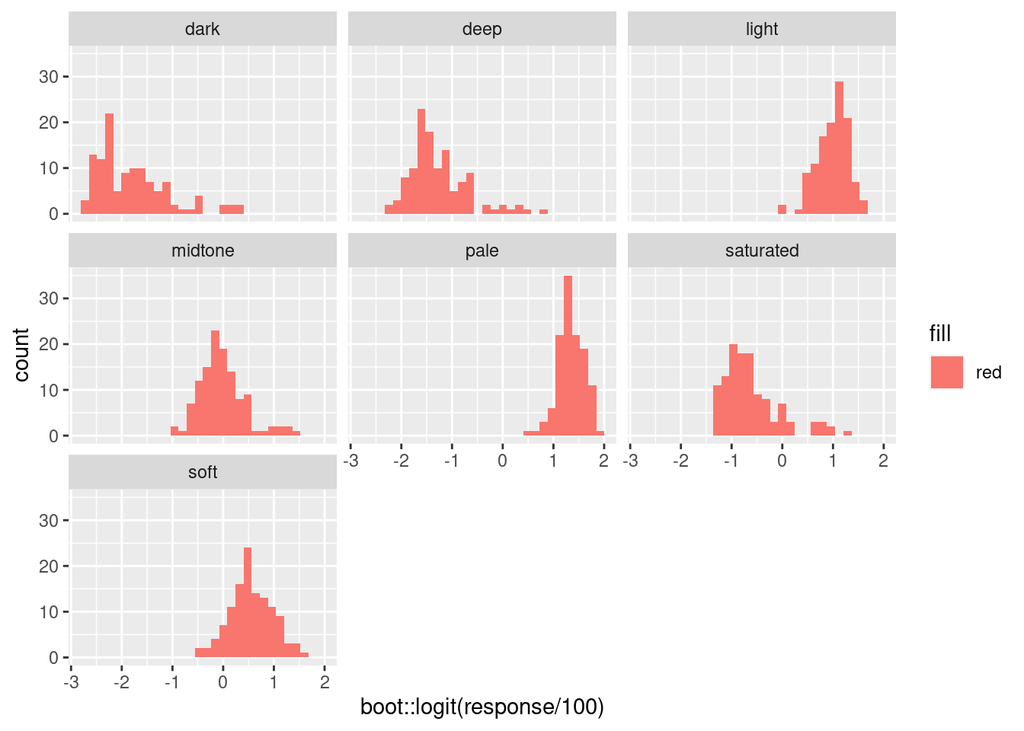

```r
#produce residual vs. fitted plot
df %>%
  ggplot() +
  geom_histogram(mapping=aes(x=boot::logit(response/100), fill='red')) +
  facet_wrap(~Lightness)
```

I do not have enough time to finish this part before the submission deadline. However, my approach to finishing part B would be to create comparison histograms that compare the logit-transformed response, y, vs histograms for the predicted y from the regression model and see how well the two align with one another. They would then be faceted by Lightness and Saturation together to obtain all possible combinations of Lightness and Saturation. This approach would serve as having the training data as a baseline (theoretical data) and using the resampled holdout data with the models as the prediction (observed data). Note that for classification this approach would be the same, although I would look at the outcome of each.

### C. Prediction Insights

I cannot complete this section, as it is reliant on part B.

although I cannot be certain as I do not have the data to debug it. It would be adjusted accordingly for the classification models with y being substituted for outcome and using some_data_frame corresponding to each combination of Lightness and Saturation required. The surface plots should show distinct predictive trends for the easier combinations, while the harder combinations would see more scatter in the color mapping. The trends may or may not be different, but we can return back to the exploration section to see if the result of the final question would be surprising or not.